# Roberts_Isabella_Blog

Isabella Roberts

12/18/2021

## Black Lives Matter

### Theory and Motivation

The African diaspora has a long history of political action and dissent utilizing social networks. The United State’s Civil Rights Movement in the 1960s relied on relational diffusion and brokerage to mobilize nationally. Furthermore, Pan Africanism and Négritude highlight the spread of black liberation movements throughout the African diaspora. Today, Black Lives Matter continues the legacies of Pan Africanism, Négritude, and the Civil Rights Movement. After the death of George Floyd on May 25, 2020, a new wave of Black Lives Matter transcended the national boundaries of the United States, where the movement began, and demonstrations sprung up all throughout the world. The protests were accompanied by a palpable shift in atmosphere. [Alicia Garcia](https://www.nytimes.com/2020/06/05/sunday-review/black-lives-matter-protests-floyd.html) suggests that “seven years ago, [BLM] were treated like we were too radical, too out of the bounds of what is possible and now, countless lives later, it’s finally seen as relevant.” There was a greater sense of urgency, greater numbers, and greater support than BLM has seen in years.

I have created a data set for the network between 21 Black Lives Matter chapters, including two chapters that are located outside the national boundaries of the United States. There are 66 edges in the network that indicate which chapters follow which other chapters on Instagram. Each node has been assigned the following attributes: chapter name; the number of protests organized between May 25, 2020 and August 31, 2020; number of Instagram followers; and number of Instagram posts. I will use this network data to investigate what motivates the ties between nodes. I hypothesize that homophily is the driving force in this network, status homophily in particular. Chapters with similar nodal attributes will form ties. If chapters have organized a similar number of protests during the summer of 2020, or have a similar amount of Instagram followers, then they will have ties between them.

```r
blm_edgelist <- read_excel("blm_network_data.xlsx")
View(blm_edgelist)
blm_attributes <- read_excel("blm_network_data.xlsx", sheet = "Nodes")
```

```
## * `` -> ...1
```

```r
blm_edgelist <- read_excel("blm_network_data.xlsx", sheet = "Edges")
blm_network <- add_node_attributes(blm_edgelist,"chapters",blm_attributes$chapter)
blm_network <- add_node_attributes(blm_network,"protests",blm_attributes$protests)
blm_network <-add_node_attributes(blm_network,"followers",blm_attributes$followers)
blm_network <-add_node_attributes(blm_network,"posts",blm_attributes$posts)
blm_network <- as_network(blm_network)
blm_network
```

```
##  Network attributes:
##   vertices = 21
##   directed = TRUE
##   hyper = FALSE
##   loops = FALSE
##   multiple = FALSE
##   bipartite = FALSE
##   total edges= 66
##     missing edges= 0
##     non-missing edges= 66
##
##  Vertex attribute names:
##     chapters followers posts protests vertex.names
##
## No edge attributes
```

### Presentation and Visualization

Let’s begin by looking at the network structure:

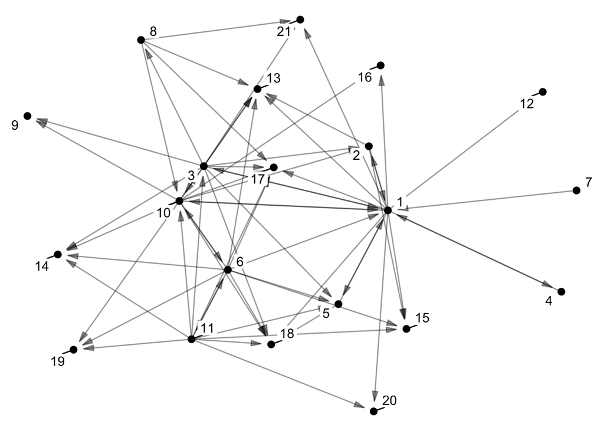

```r
node_degree(blm_network)
```

```
##  1  2  3  4  5  6  7  8 10 11 12 13 15 16 17 18 20 21  9 14 19
## 13  3 11  1  2 10  1  4 11 10  0  0  0  0  0  0  0  0  0  0  0
```

I will be using ERGM models to test my hypothesis.

### Modelling

#### Bernoulli Model

With this model we will be looking at density.

```r
library(ergm)
library(sna)
library(coda)
library(latticeExtra)
```

```r
library(migraph)
class(blm_network)
```

```
## [1] "network"
```

```r
blm_network <- as_network(blm_network)

blm.bern <- ergm(blm_network ~ edges)
```

```
## Starting maximum pseudolikelihood estimation (MPLE):
```

```
## Evaluating the predictor and response matrix.
```

```
## Maximizing the pseudolikelihood.
```

```
## Finished MPLE.
```

```
## Stopping at the initial estimate.
```

```
## Evaluating log-likelihood at the estimate.
```

```r
blm.bern
```

```
##
## Call:
## ergm(formula = blm_network ~ edges)
##
## Maximum Likelihood Coefficients:
## edges
## -1.68
```

```r
summary(blm.bern)
```

```
## Call:
## ergm(formula = blm_network ~ edges)
##
## Maximum Likelihood Results:
##
##       Estimate Std. Error MCMC % z value Pr(>|z|)
## edges  -1.6796     0.1341      0  -12.53   <1e-04 ***
## ---
## Signif. codes:  0 '***' 0.001 '**' 0.01 '*' 0.05 '.' 0.1 ' ' 1
##
##      Null Deviance: 582.2  on 420  degrees of freedom
##  Residual Deviance: 365.3  on 419  degrees of freedom
##
## AIC: 367.3  BIC: 371.4  (Smaller is better. MC Std. Err. = 0)
```

```r
exp(blm.bern$coef) / (1 + exp(blm.bern$coef))
```

```
##     edges
## 0.1571429
```

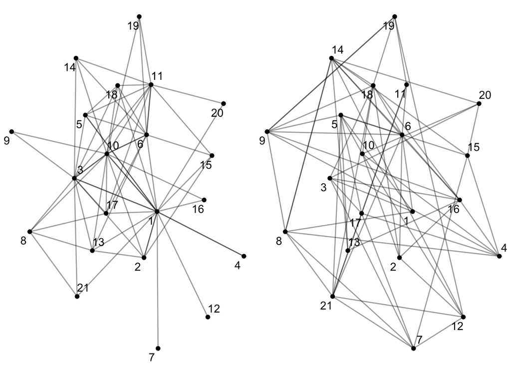

```r
blm.bern.sim <- simulate(blm.bern)
ggevolution(blm_network, blm.bern.sim)
```

#### Dyadic Dependence Model

Dyadic dependence models will allow us to test for reciprocity and/or homophily.

This model models the effect of the absolute difference in an attribute on the probability of a tie between two nodes. It will test homophily.

```r
blm.dyadic <- ergm(blm_network~edges+absdiff('protests'))
```

```
## Starting maximum pseudolikelihood estimation (MPLE):
```

```
## Evaluating the predictor and response matrix.
```

```
## Maximizing the pseudolikelihood.
```

```
## Finished MPLE.
```

```
## Stopping at the initial estimate.
```

```
## Evaluating log-likelihood at the estimate.
```

```r
summary(blm.dyadic)
```

```
## Call:
## ergm(formula = blm_network ~ edges + absdiff("protests"))
##
## Maximum Likelihood Results:
##
##                   Estimate Std. Error MCMC % z value Pr(>|z|)
## edges            -1.610903   0.163485      0  -9.854   <1e-04 ***
## absdiff.protests -0.004245   0.006068      0  -0.700    0.484
## ---
## Signif. codes:  0 '***' 0.001 '**' 0.01 '*' 0.05 '.' 0.1 ' ' 1
##
##      Null Deviance: 582.2  on 420  degrees of freedom
##  Residual Deviance: 364.8  on 418  degrees of freedom
##
## AIC: 368.8  BIC: 376.9  (Smaller is better. MC Std. Err. = 0)
```

```r
exp(blm.dyadic$coef) / (1 + exp(blm.dyadic$coef))
```

```
##            edges absdiff.protests
##        0.1664633        0.4989387
```

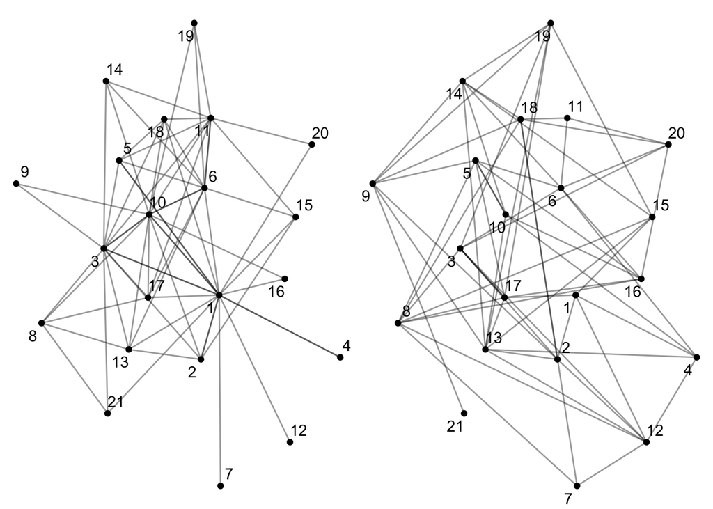

```r
blm.dyadic.sim <- simulate(blm.dyadic)
ggevolution(blm_network, blm.dyadic.sim)
```

Now, we will test for reciprocity

```r
blm.dyadic.2 <- ergm(blm_network~edges+mutual)
```

```
## Starting maximum pseudolikelihood estimation (MPLE):
```

```
## Evaluating the predictor and response matrix.
```

```
## Maximizing the pseudolikelihood.
```

```
## Finished MPLE.
```

```
## Starting Monte Carlo maximum likelihood estimation (MCMLE):
```

```
## Iteration 1 of at most 60:
```

```
## Optimizing with step length 1.0000.
```

```
## The log-likelihood improved by 0.0013.
```

```
## Convergence test p-value: < 0.0001. Converged with 99% confidence.
## Finished MCMLE.
## Evaluating log-likelihood at the estimate. Fitting the dyad-independent submodel...
## Bridging between the dyad-independent submodel and the full model...
## Setting up bridge sampling...
## Using 16 bridges: 1 2 3 4 5 6 7 8 9 10 11 12 13 14 15 16 .
## Bridging finished.
## This model was fit using MCMC.  To examine model diagnostics and check
## for degeneracy, use the mcmc.diagnostics() function.
```

```r
summary(blm.dyadic.2)
```

```
## Call:
## ergm(formula = blm_network ~ edges + mutual)
##
## Monte Carlo Maximum Likelihood Results:
##
##        Estimate Std. Error MCMC % z value Pr(>|z|)
## edges   -1.8110     0.1663      0 -10.889   <1e-04 ***
## mutual   0.6912     0.4969      0   1.391    0.164
## ---
## Signif. codes:  0 '***' 0.001 '**' 0.01 '*' 0.05 '.' 0.1 ' ' 1
##
##      Null Deviance: 582.2  on 420  degrees of freedom
##  Residual Deviance: 363.5  on 418  degrees of freedom
##
## AIC: 367.5  BIC: 375.6  (Smaller is better. MC Std. Err. = 0.1021)
```

```r
exp(blm.dyadic.2$coef) / (1 + exp(blm.dyadic.2$coef))
```

```
##     edges    mutual
## 0.1405122 0.6662251
```

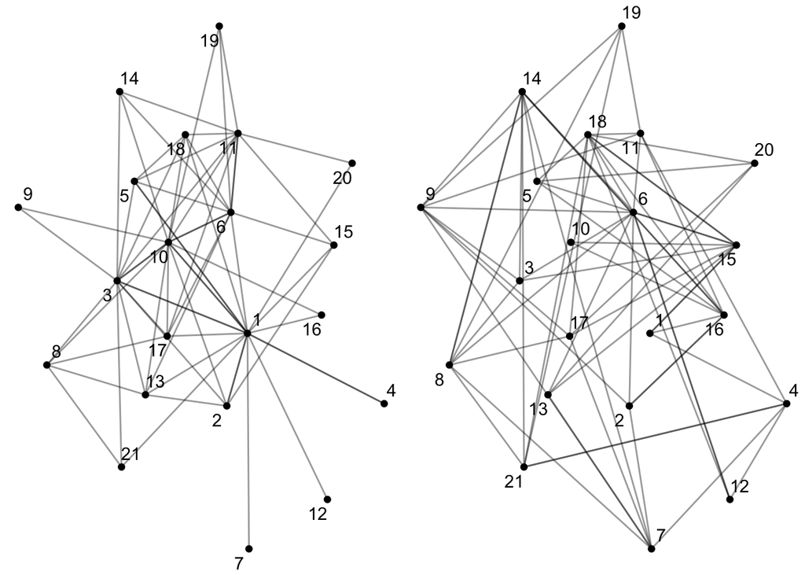

```r
blm.dyadic.sim.2 <- simulate(blm.dyadic.2)
ggevolution(blm_network, blm.dyadic.sim.2)
```

#### Goodness of Fit

Goodness of fit tests how well the models predict the observed network’s properties.

```r
blm_undir_network <- to_undirected(blm_network)
blm.bern.und <- ergm(blm_undir_network ~ edges)
```

```
## Starting maximum pseudolikelihood estimation (MPLE):
```

```
## Evaluating the predictor and response matrix.
```

```
## Maximizing the pseudolikelihood.
```

```
## Finished MPLE.
```

```
## Stopping at the initial estimate.
```

```
## Evaluating log-likelihood at the estimate.
```

```r
blm.bern.und
```

```
##
## Call:
## ergm(formula = blm_undir_network ~ edges)
##
## Maximum Likelihood Coefficients:
##   edges
## -0.9634
```

```r
summary(blm.bern)
```

```
## Call:
## ergm(formula = blm_network ~ edges)
##
## Maximum Likelihood Results:
##
##       Estimate Std. Error MCMC % z value Pr(>|z|)
## edges  -1.6796     0.1341      0  -12.53   <1e-04 ***
## ---
## Signif. codes:  0 '***' 0.001 '**' 0.01 '*' 0.05 '.' 0.1 ' ' 1
##
##      Null Deviance: 582.2  on 420  degrees of freedom
##  Residual Deviance: 365.3  on 419  degrees of freedom
##
## AIC: 367.3  BIC: 371.4  (Smaller is better. MC Std. Err. = 0)
```

```r
blm.bern.gof <- gof(blm.bern.und,  GOF = ~ degree + triadcensus + espartners - model)
blm.bern.gof
```

```
##
## Goodness-of-fit for degree
##
##          obs min mean max MC p-value
## degree0    0   0 0.02   1       1.00
## degree1    3   0 0.27   2       0.00
## degree2    3   0 0.95   4       0.14
## degree3    2   0 2.27   9       1.00
## degree4    2   0 3.63   8       0.54
## degree5    3   1 4.31  10       0.70
## degree6    3   1 3.73   8       0.94
## degree7    0   0 3.11   7       0.04
## degree8    0   0 1.42   4       0.52
## degree9    0   0 0.80   3       0.96
## degree10   2   0 0.35   3       0.12
## degree11   0   0 0.13   2       1.00
## degree12   1   0 0.00   0       0.00
## degree13   1   0 0.01   1       0.02
## degree15   1   0 0.00   0       0.00
##
## Goodness-of-fit for triad census
##
##               obs min   mean max MC p-value
## triadcensus.0 604 345 519.35 685       0.14
## triadcensus.1 409 500 574.51 623       0.00
## triadcensus.2 258 129 211.14 376       0.24
## triadcensus.3  59   8  25.00  53       0.00
##
## Goodness-of-fit for edgewise shared partner
##
##      obs min  mean max MC p-value
## esp0   5   5 13.77  25       0.08
## esp1   8  12 20.68  31       0.00
## esp2  11   3 14.10  24       0.68
## esp3  13   0  5.77  21       0.10
## esp4  11   0  1.72   9       0.00
## esp5   3   0  0.30   3       0.06
## esp6   2   0  0.06   1       0.00
## esp7   4   0  0.01   1       0.00
## esp9   1   0  0.00   0       0.00
##
## Goodness-of-fit for model statistics
##
##        obs        min       mean        max MC p-value
##      58.00      42.00      56.41      77.00       0.80
```

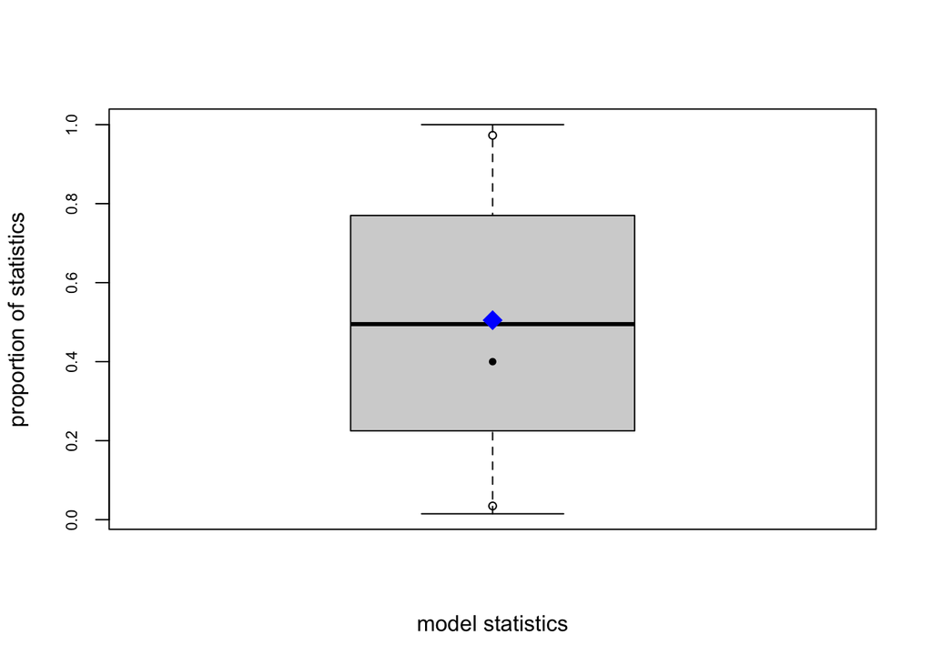

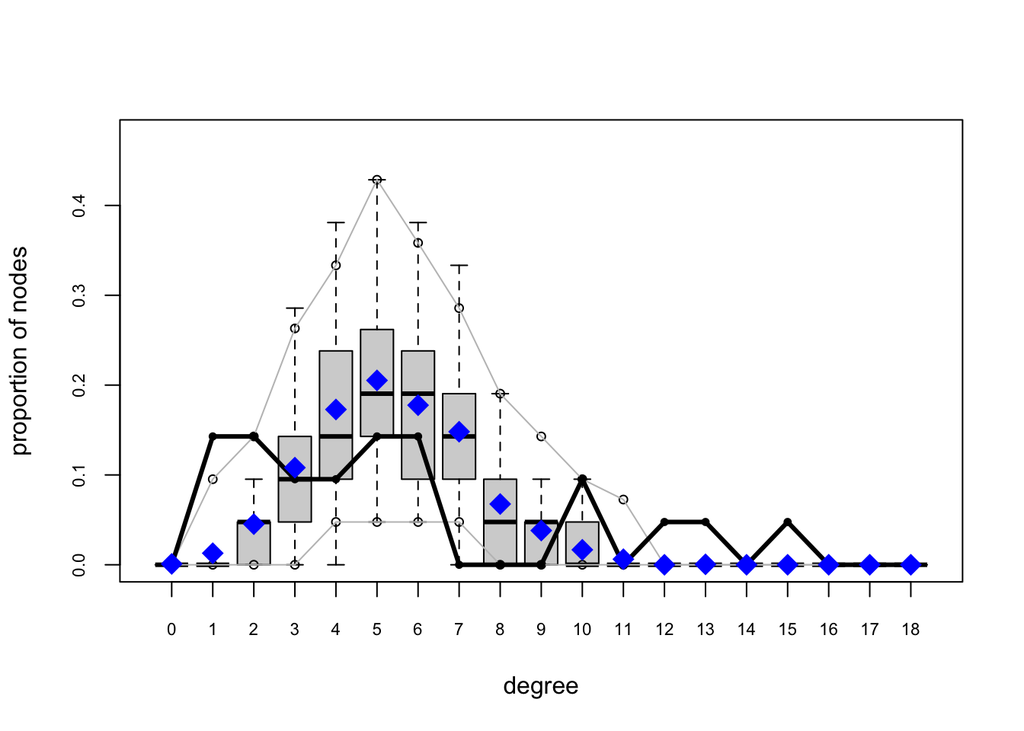

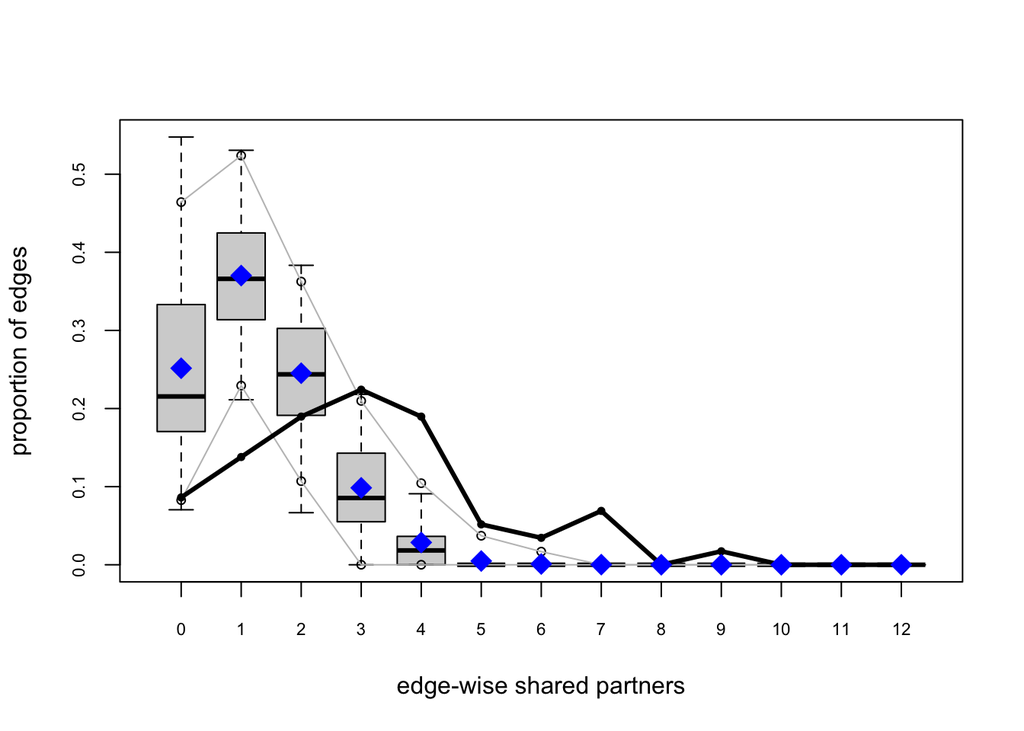

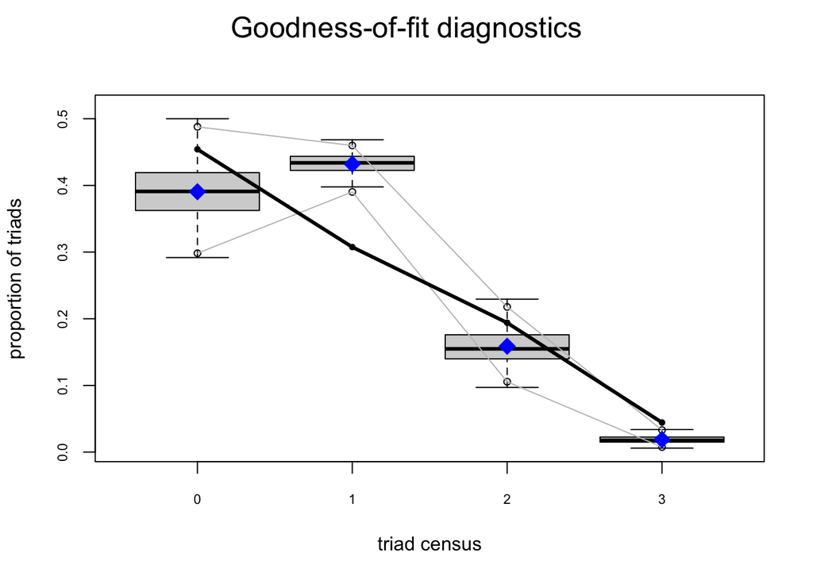

```r
plot(blm.bern.gof)
```

```r
blm.dyadic.und <- ergm(blm_undir_network~edges+absdiff('protests'))
```

```
## Starting maximum pseudolikelihood estimation (MPLE):
```

```
## Evaluating the predictor and response matrix.
```

```
## Maximizing the pseudolikelihood.
```

```
## Finished MPLE.
```

```
## Stopping at the initial estimate.
```

```
## Evaluating log-likelihood at the estimate.
```

```r
summary(blm.dyadic.und)
```

```
## Call:
## ergm(formula = blm_undir_network ~ edges + absdiff("protests"))
##
## Maximum Likelihood Results:
##
##                   Estimate Std. Error MCMC % z value Pr(>|z|)
## edges            -0.910197   0.188655      0  -4.825   <1e-04 ***
## absdiff.protests -0.003210   0.006708      0  -0.479    0.632
## ---
## Signif. codes:  0 '***' 0.001 '**' 0.01 '*' 0.05 '.' 0.1 ' ' 1
##
##      Null Deviance: 291.1  on 210  degrees of freedom
##  Residual Deviance: 247.3  on 208  degrees of freedom
##
## AIC: 251.3  BIC: 258  (Smaller is better. MC Std. Err. = 0)
```

```r
blm.dyadic.gof <- gof(blm.dyadic.und,  GOF = ~ degree + triadcensus + espartners - model)
blm.dyadic.gof
```

```
##
## Goodness-of-fit for degree
##
##          obs min mean max MC p-value
## degree0    0   0 0.03   1       1.00
## degree1    3   0 0.22   2       0.00
## degree2    3   0 0.86   4       0.12
## degree3    2   0 2.11   8       1.00
## degree4    2   1 3.51   8       0.58
## degree5    3   0 3.85   9       0.94
## degree6    3   0 3.89   8       0.84
## degree7    0   0 3.14   7       0.04
## degree8    0   0 1.86   6       0.32
## degree9    0   0 0.87   3       0.92
## degree10   2   0 0.47   4       0.14
## degree11   0   0 0.13   1       1.00
## degree12   1   0 0.04   1       0.08
## degree13   1   0 0.02   1       0.04
## degree15   1   0 0.00   0       0.00
##
## Goodness-of-fit for triad census
##
##               obs min   mean max MC p-value
## triadcensus.0 604 357 502.59 677       0.18
## triadcensus.1 409 511 576.43 628       0.00
## triadcensus.2 258 131 223.00 328       0.48
## triadcensus.3  59   7  27.98  53       0.00
##
## Goodness-of-fit for edgewise shared partner
##
##      obs min  mean max MC p-value
## esp0   5   4 13.33  29       0.08
## esp1   8   6 19.53  30       0.02
## esp2  11   2 15.47  27       0.50
## esp3  13   0  7.00  20       0.32
## esp4  11   0  2.23  11       0.02
## esp5   3   0  0.47   4       0.16
## esp6   2   0  0.20   3       0.08
## esp7   4   0  0.00   0       0.00
## esp9   1   0  0.00   0       0.00
##
## Goodness-of-fit for model statistics
##
##                  obs min   mean  max MC p-value
## edges             58  42  58.23   73       1.00
## absdiff.protests 912 497 904.10 1375       0.94
```

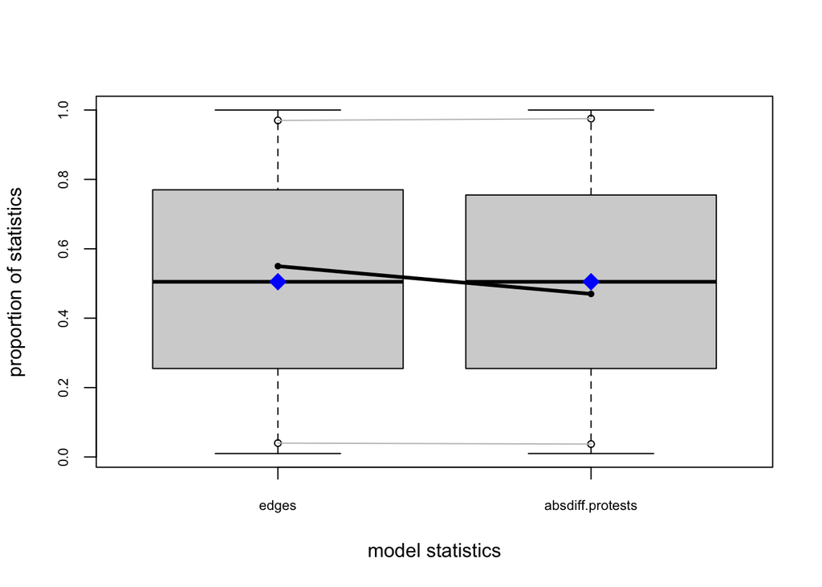

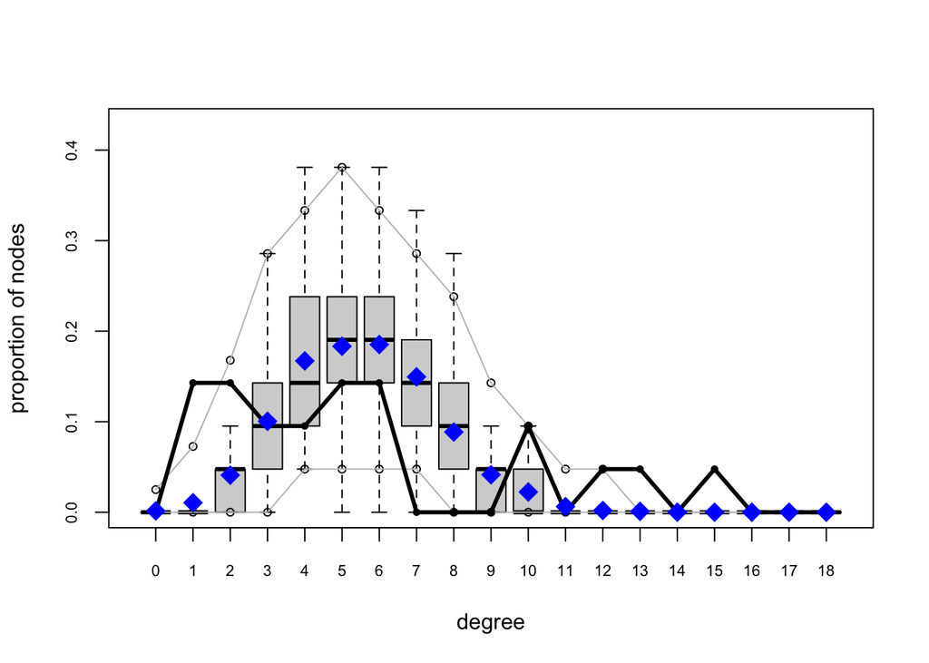

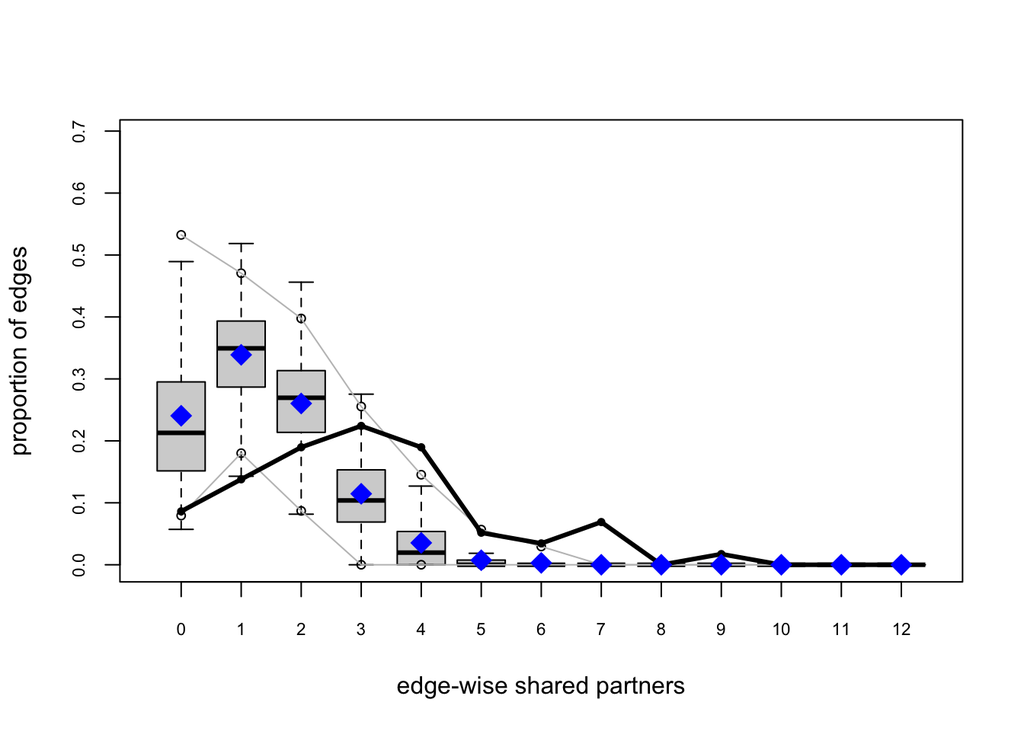

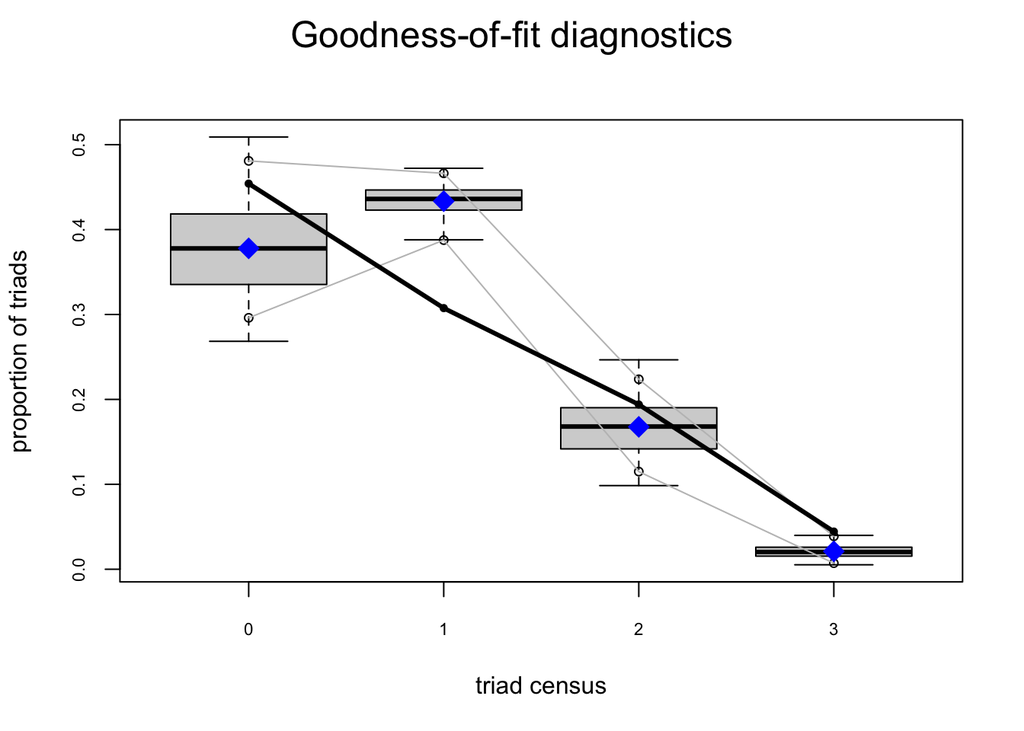

```r
plot(blm.dyadic.gof)
```

### Conclusion

The hypothesis posits that status homophily determined by the number of protests organized in the summer of 2020 influences tie formation in the observed network. However, the dyadic dependence model indicates that protest homophily does not determine tie formation. Future research could look at the impact of influence status homophily on tie formation. Chapters with similar Instagram follower counts may be more likely to form reciprocal ties.